# 马克思主义基本原理概论

ZKMjolnir

# 1 基本信息

杨晓斌  
15966876268  
Yangxiaobin611@sina.com

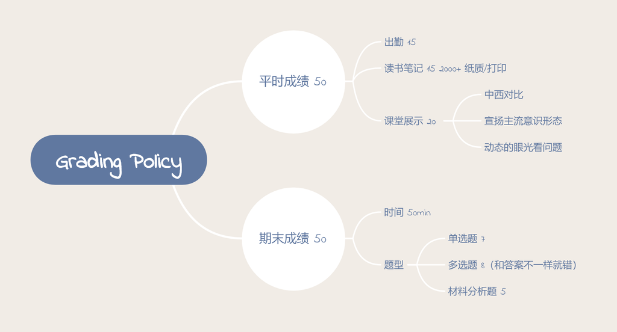

> 材料题两题：每题25分

期末考试上课序号 81 号

建议:

1. 持中立态度看意识形态（意识形态无好坏之分，只有适合不适合之分）
2. 用动态、发展的眼光

| 授课内容 | 展示主题 | 备注 |
| --- | --- | --- |
| 人是什么 | 对于社会发展来讲，集体人的必要性与优越性 | 理性，感性，实践 |
| 多样世界是否有统一本质 | 辩证分析经济发展与个人权利关系 | 让出利益获得发展 |
| 物质世界如何存在 | 科学是否是客观的 | 时间空间，运动 |
| 什么是马克思主义 | 中国特色社会主义的马克思主义本质 |  |
| 什么是哲学 | 意识形态教育的必要性 | 唯心主义，唯物主义 |
| 物质世界为何运动 | 中国为何不能照搬西方制度 | 总特征，矛盾规律 |
| 物质世界如何运动 | 梳理美国民主化与现代化发展史 | 量变到质变 |
| 如何认识世界 | 民主社会主义为何不属于社会主义，我国为何不能执行 | 否定之否定规律 |
| 什么是真理 | 历史虚无主义的错误及其成因 | 客观性，绝对性，相对性 |
| 如何认识人类社会历史 | 普世价值为何不可能 | 价值观霸权 |
| 人类社会历史有无规律 | 网络对于主流意识形态的双刃剑效应 |  |
| 谁人推动与创造历史 | 与总统制相比，人民代表大会制度的优势 |  |
| 何为资本主义制度本质 | 西方经济危机的本质与危害 | 政治经济学，资本论 |
| 如何看待当代资本主义新变化 | 资本主义与社会主义的借鉴 |  |
| 共产主义是否可能 | 共产主义理想的作用 |  |

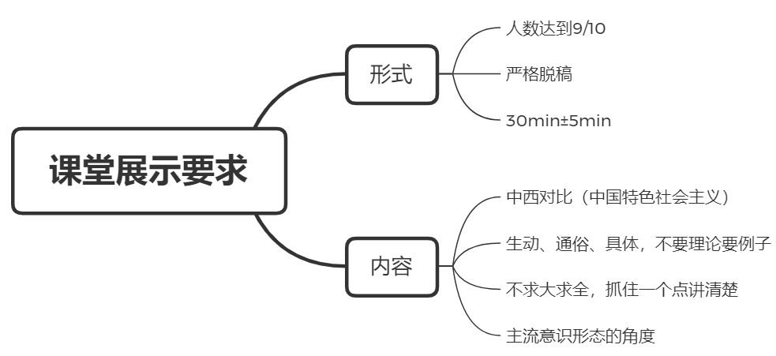

> 讲的越快考的越少，不讲的都不考，所以整理笔记的时候注意一下。

# 2 第一讲 何为人

## 2.1 一、人的存在方式

- 人是理性的存在
  - 理性的极致即为**唯心主义**
  - 形而上学（亚里士多德）

    > **形而上学**：物理学之上  
    > 形而上者谓之道，形而下者谓之器。

    > > 形：展现  
    > > 展现出的是器，没展现出的是道。

    > **亚里士多德**：存在于一切中的存在谓真正的存在  
    > **本体**：能用“是”说的具体事物，包括“质”“形”，形越多越高级，最高级的是理性之神
- 人是感性的存在
  - **机械唯物主义**
  - 拉美特利：人是机器，灵魂
- 人是包含理性和感性的存在
  - **实践是人的存在方式（马克思）**

## 2.2 二、传统实践观

- 中：
  - 王阳明：实行和践履，即知行合一
- 西：（从上到下按时间顺序）
  - 康德：  
    《纯粹理性批判》《实践理性批判》《判断力批判》
  - 费希特：  
    实践是理性指导下的一切行动，具有创造性
  - 黑格尔：  
    主观改造客观对象的创造性的**精神**活动——**能动性**
  - 费尔巴哈：  
    同生活相联系的**物质**性活动——**被动性**（狗也会进行生存本能的物质性活动）

## 2.3 三、马克思主义实践观

**★** 人类**能动地**改造世界的客观**物质性**活动（考试要答全这两点）

1. 定义：实践是人类能动的改造世界的感性物质活动
2. 特征 *P57*
   1. 直接现实性（改造世界的客观物质活动）
      1. 构成实践的要素（实践的主体、客体、手段）是可以感知的客观实在
      2. 实践受客观条件和客观规律的制约
      3. 实践能引起客观世界的变化
   2. 自觉能动性（区别于蜂巢的建造只是本能行动）
   3. 社会历史性（人的活动离不开与社会的联系）

      > 反对唯心主义，创造性要体现在物质世界
3. 基本形式 *P60*
   1. 物质生产实践：人类最基本的实践活动，解决人与自然的矛盾
   2. 社会政治实践：改造社会关系的实践活动

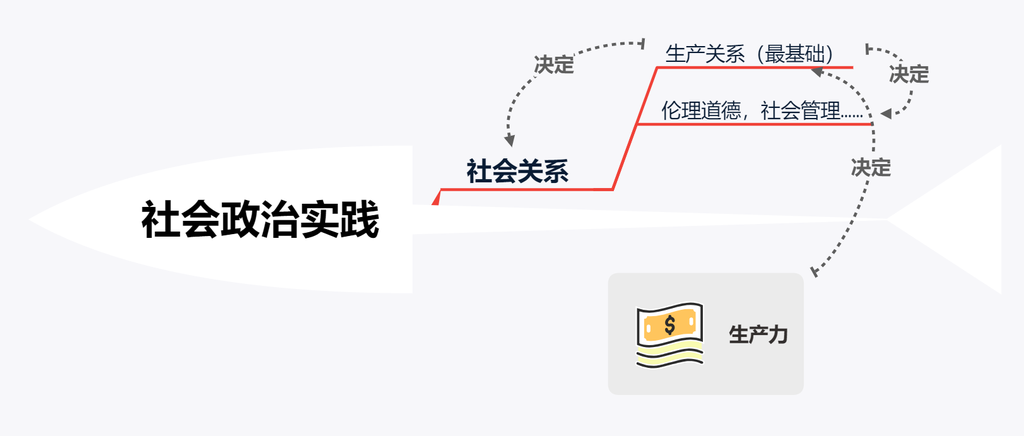

   3. 科学文化实践：人类创造精神文化产品，改造自然与社会的**准备性和探索性**的实践活动

      > 自然科学实验，社会实验如试点推行
4. **★** 全部社会生活在本质上是实践的 *P24*

   > 从实践出发理解社会生活的本质
   1. 实践是人与自然分化以及统一的历史前提和现实基础
   2. 实践是人类社会的基础，是理解和解释社会现象的钥匙
      1. 实践是社会关系形成的基础
      2. 实践形成了社会生活的基本领域
      3. 实践构成了社会发展的动力

实践为何是认识的基础[^1] *P61*

> 社会源于自然界→社会由人的活动构成（不是由人构成）→社会具有社会关系（由物质生产劳动实践所决定的分工和协作关系）→社会是由实践所产生和形成的存在形式

> 社会是随人类的产生而出现的新的物质存在形态

# 3 第二讲 什么是马克思主义

## 3.1 一、马克思主义的产生和创立

产生原因×3

### 3.1.1 （一）马克思主义是时代的产物

1. 经济基础：资本主义经济发展
   1. 工业革命促进了经济的发展
   2. 经济危机的周期性爆发
2. 阶级基础：无产主义革命斗争
   1. 背景：雇佣劳动制度代替封建生产关系
   2. 三大工人起义
      - 法国里昂工人起义
      - 德国西里西亚纺织工人起义
      - 英国宪章运动
   3. *启示 P5*  
      *1. 标志着无产阶级作为独立的政治力量登上了历史舞台*  
      *2. 觉醒了的无产阶级需要总结升华自身的斗争经验，形成科学的革命理论来指导解放斗争*

### 3.1.2 （二）是对人类文明成果的继承和创新

#### 3.1.2.1 德国古典哲学

黑格尔，费尔巴哈

黑格尔唯心辩证法

- 唯心：绝对精神的幻化——批判
- 辩证法：全面的，联系的，发展的——继承

费尔巴哈的机械唯物主义

- 不彻底的唯物主义：唯心主义历史观，不了解实践活动的意义
- 机械唯物，全盘否定辩证法

#### 3.1.2.2 英国古典政治经济学（自由主义）

亚当·斯密（1723-1790）  
大卫·李嘉图（1772-1823）

研究生产关系和社会发展规律：劳动价值论，初步讨论资本主义社会的阶级关系

- 资本主义是永恒的自然关系
- 演示生产关系和生产关系的冲突
- 站在资本主义立场，具有阶级局限性，历史片面性

#### 3.1.2.3 英法空想社会主义

欧文（英）、圣西门、傅里叶（法）  
英：罗伯特-欧文，法：沙尔-傅立叶，昂利-圣西门

1. 批判资本主义社会：没有从世界历史发展的高度阐明矛盾的历史必然
2. 新的社会制度必然取代旧的社会制度
3. 对新社会制度进行了构想

### 3.1.3 （三）马克思主义产生的自然科学基础

> 18C 下开始
1. 细胞学说：植物界与动物界有关
2. 能量守恒和转化定律：能量=运动
3. 生物进化论：人并不是神创造的，人是物质的

## 3.2 二、马克思主义的内涵和发展

1. 创新
   1. 马克思主义哲学
      1. 唯物主义和辩证法的统一（辩证的唯物主义，唯物的辩证法）
      2. 自然观和历史观的统一（自然界和人类社会）
   2. 政治经济学：资本论，对资本主义的批判和剩余价值学说的创立
   3. 科学社会主义：科学社会主义的创立
2. 发展
   1. 将理论在现实中实现：列宁
   2. 依据现实对理论进行修正：“多国胜利论”“一国胜利论”

狭义的马克思主义：马克思和恩格斯创立的基本理论，基本观点和学说的体系  
广义的马克思主义：狭义的马克思主义+后人对它的发展，即发展了的马克思主义

> 马克思主义不会过时，因为在一直发展。
> - 弗朗西斯福山《社会主义还会卷土重来吗？》
> - 凯恩斯主义
> - 《马克思的幽灵》

## 3.3 **★** 三、马克思主义的鲜明特征 *P10（以课本为准）*

以实践为基础的科学性和革命性的统一

- 科学性：科学的世界观和方法论
- 革命性：从实际出发，具有批判性
1. 科学性：对自然、社会、和人类思维发展本质和规律的正确反映
2. 革命性：彻底的批判精神和鲜明的无产阶级立场
3. 实践性：在实践中接受检验并随实践不断发展
4. 人民性：人民至上是马克思主义的政治立场
5. 发展性：与时俱进不断发展

# 4 第三讲 何为哲学

## 4.1 一、马克思主义哲学观

### 4.1.1 （一）哲学史上代表观点

- 黑格尔：关于真理的客观科学
- 罗素：介乎神学与科学之间的东西
- 胡适：哲学，乃求人生意义之学

### 4.1.2 （二）马克思主义哲学观

**★** 哲学是世界观和方法论的统一 *P20 背下来*

- 世界观：人们对整个世界的总体看法和根本观点
- 方法论：人们认识和改造世界所遵循的根本方法的学说和理论体系

## 4.2 二、哲学的基本问题

*P20* 恩格斯：“全部哲学，特别是近代哲学的重大的基本问题，是思维和存在的关系问题。”

思维和存在的关系问题：

1. 二者谁是第一位，谁是本源（**本体论**）？ 意识还是物质，精神还是自然界
   1. **唯物主义**：世界的本源是物质
   2. **唯心主义**：世界的本源是精神

      > 第一性：本源  
      > 第二性：气味，颜色……
2. 思维能否反映存在？思维能否正确认识存在？（思维与存在是否具有同一性）（**认识论**）
   1. **可知论**：世界可以为人所认识——马克思主义
   2. **不可知论**：世界不能（完全）为人所认识——康德（只知道物体的现象，感觉器官）

> 社会存在和社会意识的关系问题是社会历史观的基本问题。

### 4.2.1 （一）唯心主义

- 逻辑先在性：逻辑上 A 优先于 B
- 时间先在性：时间上 A 先产生于 B

| 客观唯心主义 | 主观唯心主义 |
| --- | --- |
| 认为某种客观的精神或原则是先于物质世界并独立于物质世界而存在的本体，而物质世界则不过是这种客观精神或原则的外化和表现，前者是本源的、第一性的，后者是派生的、第二性的 | 把个人的某种主观精神看作是世界上一切事物产生和存在的根源于基础，而世界上的一切事物则是由这些主观精神派生的，是主观精神的显现 |
| 柏拉图 朱熹：理一分殊（所谓理一分殊，就是说天地间有一个理，而这个理又能在万事万物之中得以体现，即每个事物中存在自己的一个理。朱熹首先是用“太极”的观点来论述这一思想的。） | 贝克莱：存在就是被感知 王阳明： 先生（指哲学家王阳明）游南镇，一友指岩中花树问曰：天下无心外之物，如此花树在深山中自开自落，于我心亦何相关？先生曰：你未看此花时，此花与汝心同归于寂；你来看此花时，此花颜色一时明白起来，便知此花不在你的心外。 |
| 自在逻辑先在性：本质优先于现象 但过分优先→本质独立于现象存在 | 自为逻辑先在性：认识活动的主体优先于客体存在 过分优先→将主体夸大为本源 |

### 4.2.2 （二）唯物主义

1. 朴素唯物主义
   - **物质的含义：具体事物**
   - 依据：直觉

     > 管子：水者，何也，万物之本也  
     > 赫拉克利特：这个世界是一团永恒的活火
   - 特点：朴素
2. 机械唯物主义（形而上学唯物主义）
   - **物质的含义：具体事务的结构和属性（原子）**
   - 依据：科学主义

     > 17c 英国  
     > 18c 法国  
     > 19c 德国费尔巴哈
   - 特点
     - 形而上学性：工具理性，整体是部分的组合
     - 机械性：人是机器，思维可以被量化
3. **辩证唯物主义和历史唯物主义（马克思）** 见下一讲

马克思对旧唯物主义的批判:

1. 时间先在性：认识活动中，旧唯物主义认为在时间上客体优先于主体
2. 逻辑先在性：自然本体化，人只是物品
3. 危害：
   1. 导向不可知理论：人的认识的积极作用被否定
   2. 导向唯心主义或给其可乘之机：物质概念不严谨（机械唯物主义对物质的理解建立在当时自然科学发现的基础之上，故可能经不起自然科学进一步发展的检验以及唯心主义的进攻）
   3. 不能将唯物主义贯彻于社会历史领域：历史不是物质

关于本体论的分类如上，认识论只需要知道：

- 可知论：马克思
- 不可知论：休谟

# 5 第四讲 何为世界本质

**★** 辩证唯物主义（*背下来*）：**物质是标志着客观实在的哲学范畴，这种客观实在，是人通过感觉感知的，它不依赖于我们的感觉而存在，只为我们的感觉所复写，摄影，反映**（列宁）

> 物质并不是科学上的具体事物或结构，而是作为本质概括的哲学范畴

**★** *P22*

1. 坚持了唯物主义一元论与唯心主义一元论和二元论划清界限  
   物质最本质的规定是客观实在，是脱离于意识存在的，意识不过是物质的反映，故不可能成为世界的另一本源

   > 一元论（Monism）是认为世界只有一个本原的马原哲学学说，是本体论的分支的一个哲学学说。唯物主义的一元论肯定世界的本原是物质，唯心主义的一元论肯定世界的本原是精神。
2. 坚持能动的反映论和可知论，物质这一客观存在是可以认识的对象：反对旧唯物，批判了不可知论
3. 体现了唯物论和辩证法的统一：克服了形而上学唯物主义的缺陷
4. 唯物主义自然观和唯物主义历史观的统一：彻底的唯物主义

物质的唯一特性是**客观实在性**. （物质范畴就是标志客观实在的哲学范畴）

- 物质不依赖于人的意识存在
- 物质可以为人的意识所反映

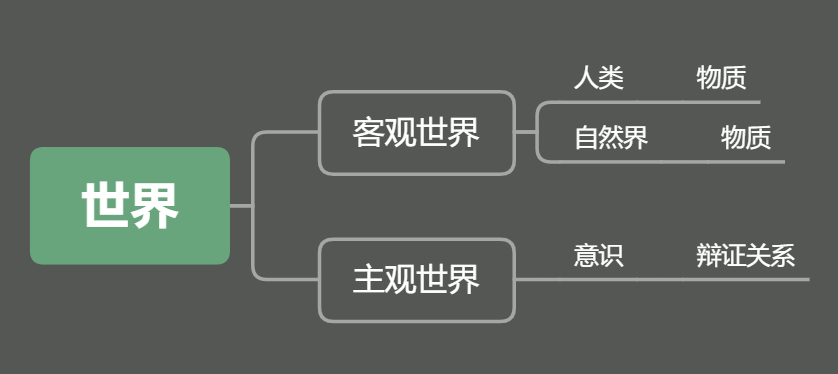

## 5.1 一、自然世界物质性

显然，略

## 5.2 二、人类社会的物质性

*P29:*

1. *人类社会是物质世界的组成部分*
2. *人类获取生活资料的活动是物质性的活动*
3. *人类社会存在和发展的基础是物质资料的生产方式*

## 5.3 三、意识与物质的辩证关系

### 5.3.1 （一）意识的起源

1. 意识是自然界长期发展的产物 *P25*
   1. 无生命物质的反应特性
   2. 低等生物的刺激感应性
   3. 高等动物的感觉和心理（大脑）
   4. 意识（人脑）

      > 这里认为只有人才有意识，拥有大脑不代表拥有意识
2. 意识是人脑的机能

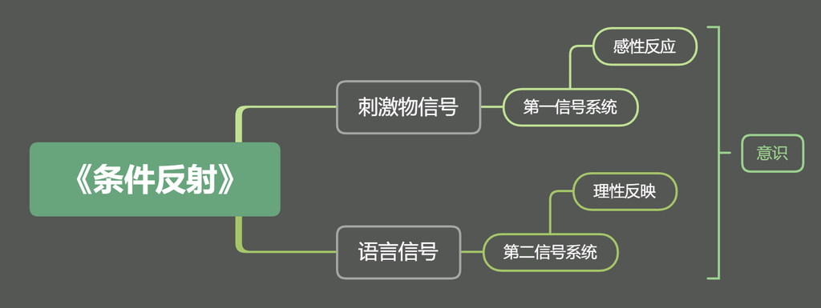

3. 意识更是社会（历史发展）的产物 *P25*
   1. 劳动为意识的产生和发展提供了客观需要
   2. 劳动和交往中形成的语言促进了意识的发展

### 5.3.2 （二）意识的本质

**★** 意识：**对客观世界的反映**  
*P25* 从意识本质上来看，意识是人脑这样一种特殊物质的机能和属性，**是客观世界的主观映像**

1. 非机械，非狭隘，非僵化
2. 有正确意识和错误意识（飞马，独角兽）

### 5.3.3 （三）意识的能动作用（意识对物质具有反作用）

1. 含义：意识的能动性/主观能动性
2. 具体表现 *P26*
   1. 意识具有目的性，计划性
   2. 意识具有主动创造性
   3. 意识可以指导人们改造客观世界
   4. 意识具有指导，控制人的行为和生理活动的作用

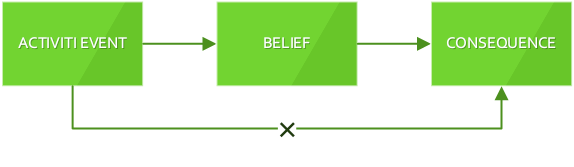

### 5.3.4 （四）主观能动性与客观规律性的统一

1. 规律及其客观性

   > 规律：事物变化的相对重复性，具有客观性，稳定性
   1. 规律是本质的、必然的、稳定的
   2. 客观性即不以人的意志为转移
2. **★** 尊重客观规律与发挥主观能动性的辩证统一 *P27*
   1. *尊重客观规律是正确发挥主观能动性的前提*
   2. *只有发挥主观能动性才能正确认识和利用客观规律*  
      主观能动性是人区别于动物的根本标志
   3. 尊重客观规律与发挥主观能动性是辩证统一的，实践是客观规律性与主观能动性统一的基础

# 6 第五讲 世界如何存在

## 6.1 一、物质的运动与静止 *P23*

1. 运动是物质的存在方式和根本属性（运动是物质的固有属性）
2. 运动是标志一切事物和现象的变化及其过程的哲学范畴。
3. 物质与运动不可分割

   > 形而上学：孤立片面静止  
   > 牛顿认为物质倾向于不动  
   > 非风动、亦非幡动，仁者心动——惠能
4. 绝对运动与相对静止的辩证关系：既对立又统一  
   无条件的绝对运动和有条件的相对静止

## 6.2 二、时间与空间 *P23*

（一）时空的内涵与特征  
时间和空间是物质运动的存在形式（物质运动和时空不可分割）

- 时间：物质运动的持续性、顺序性，特点是一维性
- 空间：物质运动的广延性、伸张性，特点是三维性
1. 时空同物质一样具有客观实在性，脱离物质谈时空会导致唯心
2. 脱离时空谈物质会导致机械唯物主义，形而上学

方法论：**要求我们想问题，办事情都要以具体的时间、地点和条件为转移**

# 7 第六讲 物质世界为何运动

## 7.1 前言：关于辩证法

> 马克思主义辩证法

辩证法的历史：

1. 苏格拉底：在**对话辩驳**中求得概念之理解
2. 柏拉图：逻辑，用**纯粹思辨**求得形而上学知识
   1. 理性可以认识本质
   2. 柏拉图认为**论辩术是对知识的伤害**，容易通向诡辩
3. 康德：**不可知论**，辩证法不能获得形而上学知识
4. 黑格尔：为辩证法的肯定性和积极性证明

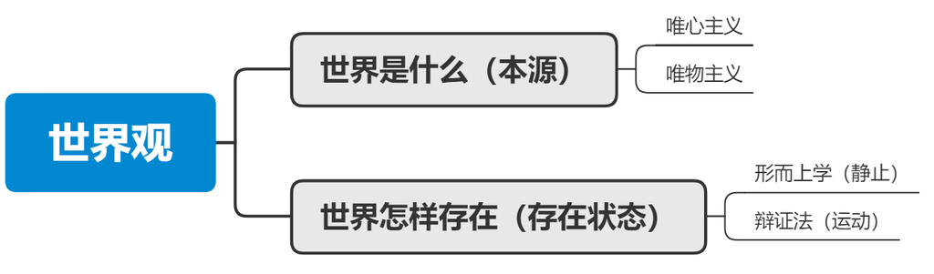

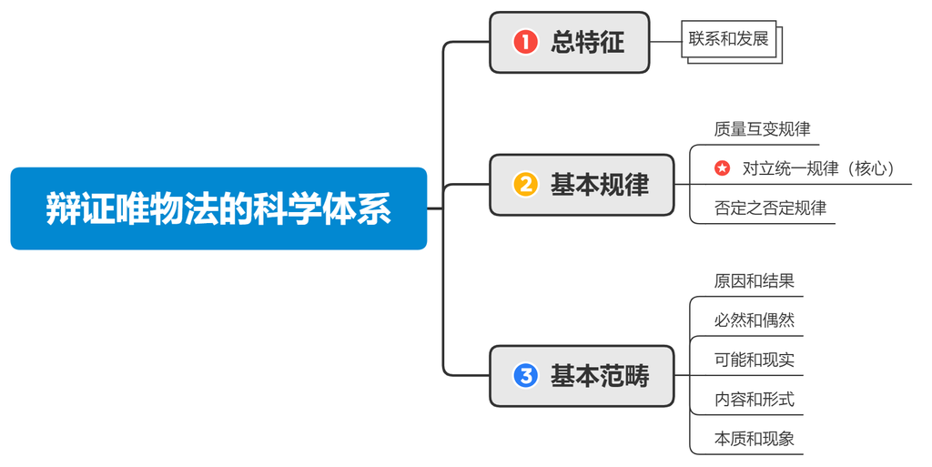

### 7.1.1 辩证唯物法的科学体系

1. 总特征  
   联系和发展

   > 联系和发展是有序的，因为背后有基本规律
2. 基本规律[^2]
   1. 质量互变规律：联系、发展的形式、状态 **HOW**
   2. 对立统一规律（核心，对立统一规律是事物发展的根本规律）：联系、发展的动力、源泉 **WHY**
   3. 否定之否定规律：联系、发展的方向、道路 **WHERE**
3. 基本范畴（没讲）
   1. 原因和结果
   2. 必然和偶然
   3. 可能和现实
   4. 内容和形式
   5. 本质和现象

### 7.1.2 康德补充

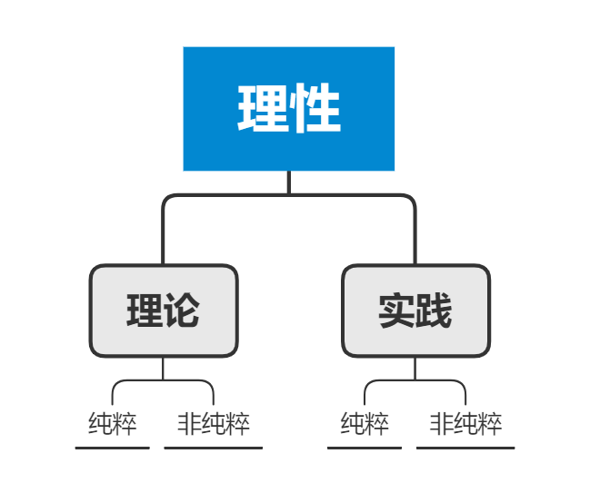

非纯粹：掺杂了经验  
世界分为现实世界和本质世界，理性属与现实世界，欲进入本质世界而不得

《纯粹（理论）理性批判》

> 该书首先确定了人的认识的形式和范畴，然后论证这些先天的形式和范畴只适用于现象界，而不适用于超验的本体——自在之物。认为对自在之物的认识不是人有限的认识能力所能达到的。所以得出结论，理论理性低于实践理性，科学知识应该让位给宗教信仰。

《（非纯粹）实践理性批判》

> 在该书中，康德首次确定了精神的永存和上帝的存在。书中讨论了生活中的至善问题，康德认为人在绝对服从道德律令的情况下，不应该只是去寻找快乐，而应该去寻找上帝赐予人们的幸福。该书的重要理论意义在于，它把人的主体性问题突出出来，强调了人格的尊严与崇高，表现了强烈的人本主义精神。

**★** **康德的辩证法是马克思所反对的形而上学**

## 7.2 一、事物的普遍联系

1. 联系的定义：事物内部各要素之间以及事物之间相互影响、相互制约、相互作用的关系
2. 联系的特点：
   1. 客观性：联系是事物本身所固有的，一切事物都具有客观性  
      方法论：**联系的客观性要求我们从客观事物本身固有的联系出发去认识事物**
   2. 普遍性 *P31*  
      方法论：**全面地整体地看待**
      1. 内部互相联系【结构性】
      2. 外部相互联系【不孤立】
      3. 世界相互联系【统一整体】
   3. 多样性
   4. 条件性

方法论：**我们要善于分析事物的具体联系，确立整体性、开放性观念，从动态中考察事物的普遍联系**

> > 六度分离理论 六度分离（六度区隔）理论（Six Degrees of Separation）：“你和任何一个陌生人之间所间隔的人不会超过五个，也就是说，最多通过五个人你就能够认识任何一个陌生人。”

## 7.3 二、事物的永恒发展 *P32*

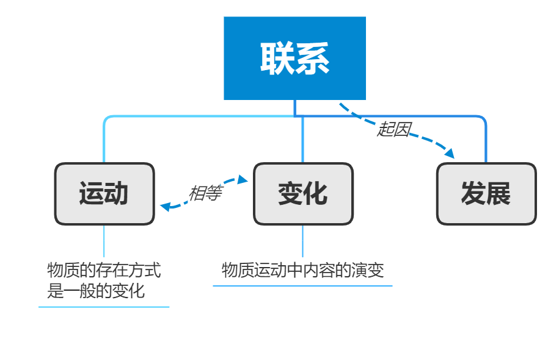

1. 发展的起因 *P32*：相互作用必然导致事物的运动、变化和发展
2. 发展的实质：新事物产生，旧事物灭亡 （新旧的判断标准：是否符合历史发展趋势，而非时间先后）
3. 发展是一个过程：世界不是既成事物的几集合体，而是过程的集合体

## 7.4 三、对立统一规律

对立统一规律是唯物辩证法的实质和核心 *P37*

1. **对立统一规律揭示了事物普遍联系的根本内容和变化发展的内在动力，从根本上回答了事物为什么会发展的问题**
2. **对立统一规律是贯穿量变质变规律，否定之否定规律以及唯物辩证法基本范畴的中心线索**
3. **对立统一规律提供了人们认识世界和改造世界的根本方法——矛盾分析方法**

矛盾分析方法

1. 矛盾
   1. 逻辑矛盾：思维过程中违反逻辑规则所造成的不可调和的对立——不可调和

      > 无坚不摧的矛与无所不挡的蹲是否可以同时存在
   2. 辩证矛盾：反映事物的内部和事物之间对立统一关系的哲学范畴——可调和

      > 我的学生说多挺多，说少也挺少  
      > 辩证法是对立面的统一的学说
2. 矛盾的同一性和斗争性

   | 区别 | 同一性（统一性） | 斗争性（对立性） |
   | --- | --- | --- |
   | 含义 | 矛盾双方相互吸引，相互连结的属性和趋势 | 矛盾双方相互对立，相互分离的属性和趋势 |
   | 表现 | 一定条件下相互依存，相互贯通/渗透/包含，并在一定条件下相互转化 上、下必须共存 | 相互区别，相互排斥 哲学里面，只要不同就是斗争，和生活中不同 |
   | 条件 | 相对的，有条件的 | 绝对的，无条件的 |
   | 联系 |  |  |

   同一性以斗争为前提，斗争性寓于同一性之中，为同一性所制约，矛盾双方既对立又统一，推动事物运动变化发展
3. 普遍性与特殊性 *P38*
   1. 普遍性：处处有矛盾，时时有矛盾
   2. 特殊性：每个矛盾都不同

**SUMMARY:**  
矛盾

1. - 根本矛盾 非根本矛盾
   - 主要矛盾 次要矛盾
   - 矛盾的主要方面与次要方面
2. - 两点论，重点论的统一
   - 具体问题具体分析

> 列宁在《我们的纲领》中指出：“马克思的理论是总的指导原理，而这些原理的应用具体地说，在英国不同于法国，在法国不同于德国，在德国又不同于俄国。

> 休克疗法

> 不要羡慕别人有的，想要轻易照搬，因为别人可能也是经历了一段时间才有现在的光鲜亮丽

# 8 第七讲 物质世界如何运动

## 8.1 一、质量互变规律

1. 质、量、度 *P40*
   1. 质：事物区别于其他事物的内在规定性  
      **质与事物直接同一**
   2. 量：事物可以用数量关系表示的规定性  
      **同质的事物靠量区分，量和事物并不同一**
   3. 度：一定事物保持自己质的稳定性的数量界限，即事物的限度、幅度、范围，**是质和量的统一体**  
      本质是量，超过了这个量的限度，它就从量变到质变  
      方法论：**适度原则**
2. 量变与质变 *P40*
   1. 概念
      1. 量变：

         > 是实物数量的增减和组成要素排列次序的变动，是保持事物的质的相对稳定性的不显著变化，体现了事物发展渐进过程的连续性
      2. 质变：

         > 是事物性质的根本变化，是事物由一种质态向另一种质态的飞跃，体现了事物发展渐进过程和连续性的中断
         1. 爆发式飞跃（迅速取代）：新旧事物斗争剧烈
         2. 非爆发式飞跃：旧事物逐渐消失，新事物逐渐产生
      3. 区分标准：事物的变化是否超出度的界限
      4. 量变和质变的对立统一规律  
         形而上学只看到量变/只看到质变，灾变论  
         方法论：
         1. **注意量的积累**
         2. **抓住机遇，促成质变飞跃**
      5. 量变和质变的辩证关系 *P40*
         1. 量变是质变的必要准备
         2. 质变是两边的必然结果
         3. 量变质变相互渗透

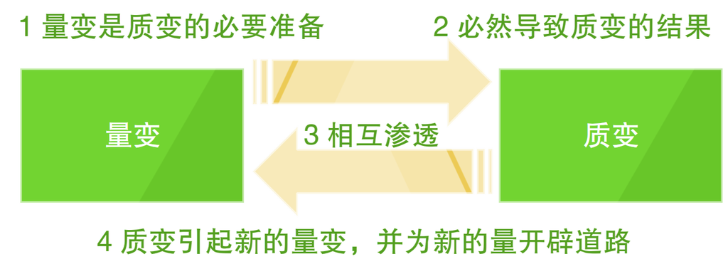

## 8.2 二、否定之否定规律 *P41*

1. 肯定与否定
   1. 肯定方面：维持现成事物存在的因素
   2. 否定方面：促成事物灭亡的因素
   3. 肯定与否定相互区别又相互统一，**同时存在于任何事物中**
      1. 静态的统一：黑格尔——肯定与否定相等同（肯定一个事物的同时也否定了此事物，我高，那么我就不低）
      2. 动态的统一：递进与包含（包含着肯定的否定）
2. 辩证否定观 *P41*
   1. 否定是事物的自我否定
   2. 否定是发展的环节：发展是新事物的产生，旧事物的灭亡
   3. 否定是新旧事物联系的环节
   4. **辩证否定的实质是“扬弃”** 既批判又继承，既克服其消极因素又保留其积极因素。
3. 否定之否定

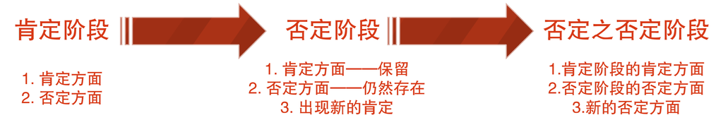

   在一个周期里面，事物达到完善  
   事物总是向着对立面发展，而对立面又总向着自己的对立面发展，所以经过两次否定，新事物与旧事物有形式上的统一。就像正弦函数，y 轴来看总是曲折反复，x 轴看是一直在前进。
   1. 前进性
      1. 每一次否定都是质变，都把事物推到新的阶段
      2. 每一次周期都是开放的，不存在不被否定的终点
   2. 曲折性：回复性，倒退性

方法论：**科学分析的态度，反对肯定一切和否定一切的形而上学否定观**

# 9 第八讲 如何认识世界

## 9.1 一、认识活动的本质 *P63*

      > 我是上帝对上帝的认识
    - 主观唯心主义认识论：认识是主观自生，头脑中固有的，物决定感觉和思维

      > 柏拉图认为“认识即回忆”
  - 旧唯物主义认识论

    > 洛克：知识并不来源于上帝，知识来源于经验（反映论）
  - 总结：
    - 唯心主义认识论宣扬了主观能动性，**夸大了主观能动性，使精神独立于世界之外**
    - 旧唯物主义认识论宣扬了物质性，**但物质性只是被动的反应，忽略了人的作用**
- 辩证唯物主义认识论
  - **本质：主体在实践基础上对客体的能动反映（认识是对实践的反应，而不是对事物本质的反应）**
    - 人与自然首先是改造与被改造，在此基础上才是反映
    - 认识桌子是认识时间，随着时间深入，实践跟进，认识能够加深/改变

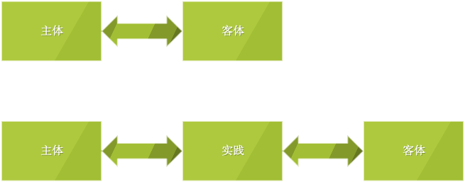

    > 人对世界的能动反映/认识是充满矛盾运动的辩证过程
  - 与之前认识论的区别 *P65*
    - 把实践的观点引入认识论
    - 把辩证法应用于反映论考察认识的发展过程
    - 从主体直接认识客体，到主体通过认识实践认识客体
  - 特点：摹写性与创造性
    - 买桌子：给男生卖和给女生卖话术不同，是因为不同的人有不同的认知
    - 伽利略理想实验，现实世界不会出现，但是是现实世界的合理推论（不是唯心主义）

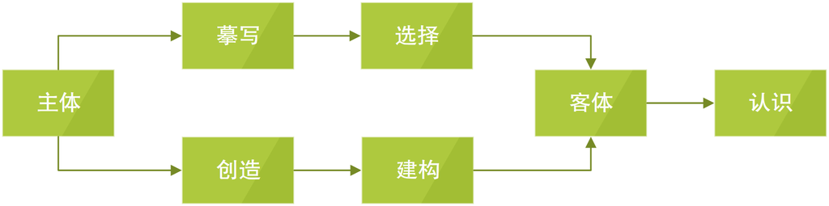

实践为何是认识的基础 *P61*

- 实践是认识的**来源**：不是唯一来源，书籍也是认识的来源

  > 不登高山，不知山之高也
- 实践是认识发展的**动力**：为了发展的需要
- 实践是认识的**目的**：参考本页（二）从认识到实践
- 实践是检验认识真理性的唯一**标准** [^3]

## 9.2 认识活动的规律

> 人的认识过程
> - 既表现为实践基础上由感性认识到理性认识，再从理性认识到实践的具体认识过程；
> - 又表现为从实践到认识，再从认识到实践的循环往复和无限发展的总过程。

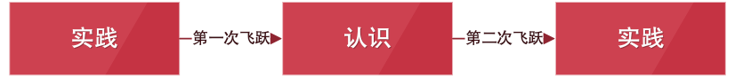

### 9.2.1 （一）从实践到认识

- 感性认识 *P67*
  - 人们在实践的基础上，由感觉器官直接感受到的认识
  - 感觉（个别属性）→知觉（整体反映）→表象（对过去的感觉和知觉的回忆）
  - 特点：
    - 直接性：直接感知、无中介
    - 具体性：对特定事物的感性认识
- 理性认识

  > 理性认识不一定是对的
  - 概念（一般属性/本质属性）→判断→推理（对未知事物合乎逻辑的推理）
  - 特点：
    - 间接性：**理性认识以感性认识为基础，没有直接感知事物**
    - 抽象性：认识一般事物
- 感性认知和理性认识的辩证关系 *P68*
  - 理性认识依赖于感性认识，以感性认识为基础
  - 感性认识有待于发展和深化为理性认识
  - 感性认识和理性认识互相渗透，互相包含
- 从感性认识到理性认识过渡的基本条件 *P69*

  > 感性认识产生于实践，并在实践的基础上过渡到理性认识。
  - 投身实践，深入调查，获取十分丰富和合乎实际的感性材料
  - 经过理性思考，将丰富的感性材料加以去粗取精，去伪存真，由此及彼，由表及里
- 重视非理性因素的积极作用 *P70*
  - 非理性因素是指认识主体的情感和意志

### 9.2.2 （二）从认识到实践

1. 认识世界的目的是为了改造世界
2. 认识的真理性只有在实践中才能得到检验和发展

## 9.3 三、认识活动的不断反复和无限发展

- 认识辩证运动的总过程与总特征：无限性反复性  
  实践→认识→再实践→再认识

  > 波浪式前进，螺旋式上升
- 原因
  - 主客观条件的限制，对事物的认识无法一次完成
  - 对整个无限的物质世界以及其发展过程来说，认识永远不会完成
- 认识的具体性与历史性
  - 具体性：主观认识要同**一定时间、地点、条件下**的客观实践相符合
  - 历史性：主观认识要同**特定历史发展阶段**的客观实践相适应

# 10 第九讲 何为真理

## 10.1 一、真理及其检验标准 *P75*

> 真理是由相对真理走向绝对真理的永无止境的过程  
> 马克思主义是客观真理
1. 真理定义：是对客观事物本质及其规律的正确反映
2. 真理的特征
   1. 客观性（真理问题上的唯物性）  
      客观性是指真理的内容是对客观事物及其规律的正确反映
   2. 绝对性和相对性
      1. 绝对性：同谬误有原则的界限，认识每前进一步，都更加接近物质世界
      2. 正确认识是有限度的
         1. 深度：深刻程度，正确程度有限
         2. 广度：真理只是对无限物质世界发展中某一阶段/方面
      3. 辩证统一 *P78* : 二者相互依存，相互包含  
         **真理绝对性与相对性的根源：人类认识世界能力的无限性与有限性，绝对性与相对性的矛盾。** 人类思维能够认识世界但认识水平受许多因素的限制

         反对割裂绝对性和相对性：形而上学真理观
         1. 绝对主义：教条主义
         2. 相对主义：不可知论，诡辩论

         绝对真理性与相对真理统一性原理的方法论意义：
         1. 这一原理要求我们既要反对绝对主义真理论，又要反对相对主义真理论。
         2. 为我们提供了对待马克思主义的正确态度，这就是坚持和发展辩证统一的态度。
3. 真理与谬误
   1. 相互对立：本质区别
   2. 相互联系/依存：有谬误才知何为真理
   3. 相互斗争：去伪存真
   4. 相互转化

   > 注意，没有相互包含的关系
4. 真理的检验标准：**实践是检验真理的唯一标准**
   1. 真理是主观和客观的结合，是人们对客观事物及其发展规律的正确反映
   2. 实践可以联系主观与客观（直接现实性）（成功了就是真理失败了就是谬误）

   实践标准的确定性与不确定性 *P84*
   1. 确定性：唯一性（实践是检验真理的唯一标准）
   2. 不确定性：条件性（实践对真理的检验不能一次完成，例如我们不会轻易否定课本）

（下面好像不是重点）  
价值及其评价标准  
价值及其特性  
实践的两种尺度

1. 实践的真理尺度：按照客观规律
2. 实践的价值尺度：符合人的目的

价值

1. 价值的含义：是揭示外部客观世界对于满足人的需要的意义关系的范畴，具有特定属性的客体对于主体需要的意义
   1. 主体和客体之间的关系
   2. 价值是客体对主体积极的作用
2. 价值的特性
   1. 客观性：人的需要有客观性，
   2. 主体性：对不同的主体价值不同
   3. 社会历史性
   4. 多维性

# 11 第十讲 唯物史观（一）

> 历史唯物主义  
> 唯物主义历史观

## 11.1 一、社会基本矛盾 *P106*

矛盾（对立统一规律）  
**人类社会物质（社会存在）与精神（社会意识）的矛盾。**

1. **生产力和生产关系的矛盾——社会存在**
2. **经济基础和上层建筑的矛盾——社会意识**

### 11.1.1 1. 社会存在

1. 含义：社会生活物质条件
2. 内容：
   1. 自然地理环境：自然界（属于人类社会）
   2. 人口因素
   3. 物质生产方式（生产方式属于社会存在）
      1. 生产力：人和自然的交换关系
      2. 生产关系：人和人之间的交换关系

> 通过后面的分析：生产方式是社会发展的决定力量

#### 11.1.1.1 地理环境的作用 *P107*

1. 地理环境影响劳动生产率的高低（如旅游业，交通枢纽）
2. 地理环境影响社会分工的发展和生产形势的多样化
3. 地理环境的平衡与稳定（生态平衡）对社会生活有重要意义

**地理环境不是社会发展的决定力量：**

1. 不能决定社会的性质和制度
2. 对社会的影响要由社会发展程度决定

#### 11.1.1.2 人口因素对社会发展的作用

**人口因素对社会发展不起决定作用：**

1. 人口状况不能决定社会制度的性质
2. 人口状况不能决定社会制度的更替

#### 11.1.1.3 **★** 生产方式是社会发展的决定力量 *P108*

1. 首先：物质生产活动以及生产方式是人类社会赖以存在和发展的基础，是人类其他一切活动的首要前提
2. 其次：物质生产活动以及生产方式决定着社会的结构、性质和面貌，制约着人们的经济生活、政治生活和精神生活等全部社会生活
3. 最后：物质生产活动及生产方式的变化发展决定着整个社会历史的变化发展，决定社会形态从低级向高级的更替和发展

*P29 人类社会具有物质性* [^4]

### 11.1.2 2. 社会意识

1. 含义：社会生活的精神方面
2. 组成：政治法律思想，道德，艺术，宗教，哲学，科学等
   1. 意识形态：反映经济关系，阶级关系的社会意识（政治法律思想，道德，艺术，宗教，哲学）（意识形态不是客观中立的）
   2. 非意识形态
      1. 自然科学
      2. 语言学
      3. 形式逻辑

#### 11.1.2.1 自然科学补充

自然科学在未进入生产关系之前不属于生产力  
自然科学属于非意识形态，**生产方式**决定**非意识形态**  
科学源于实践，实践决定认识的来源，目的，动力，是真理的检验标准

- 社会政治实践
- 科学文化实践
- 物质生产实践——核心是生产方式

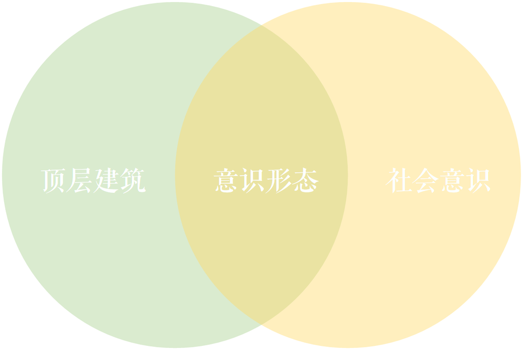

### 3. 社会意识的产生以及其与社会存在的辩证关系 *P111*

2. 社会存在决定社会意识（实践是意识的来源，社会存在是社会意识的根本来源），社会意识反映社会存在
3. 社会意识具有相对的独立性（独立于社会存在）
   1. 社会意识与社会存在发展不同步（历史继承性，如封建复辟）
   2. 社会意识水平与经济发展水平不平衡
   3. 社会意识反作用于社会存在（如封建复辟）

## 11.2 二、社会发展规律

> 土地是劳动资料还是劳动对象取决于在做什么：耕地

### 11.2.1 1. 生产力与生产关系

#### 11.2.1.1 生产力

生产力含义：人类在生产实践中形成的改造和影响自然以使其适合社会需要的物质力量。

生产力的系统结构：

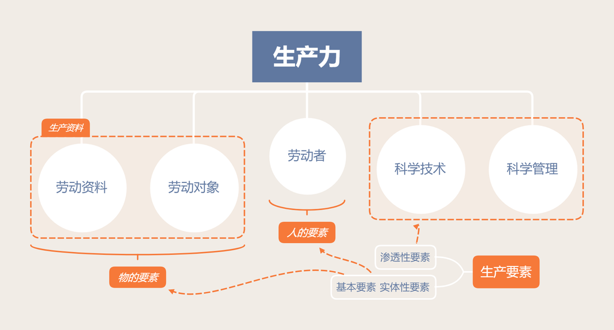

1. 劳动资料/劳动手段：人们在劳动过程中所运用的物质资料或物质条件，其中最重要的是生产工具。
2. 劳动对象：自然物和原料（生产深度加工的对象）
3. 劳动者：人，劳动者是生产力中最活跃的因素，在生产力中起主导作用

#### 11.2.1.2 生产关系 *P117*

1. 含义
   - 生产关系是人们在物质生产过程中形成的不以人的意志为转移的经济关系
   - 生产关系是社会关系中最基本的关系
2. 分类
   - 生产资料所有制关系 **（最基本）** ：表明了人们对生产资料的地位，决定着生产资料和劳动者结合的方式 （私有制、公有制）  
     **生产资料所有制关系是最基本的**
     - 决定**人与人之间的关系**，没有生产资料，只能出卖自己的劳动力
     - 也决定着**产品分配关系**，生产出来产品归谁
   - 生产中人与人的关系：
   - 产品分配关系

#### 11.2.1.3 **★** 生产力与生产关系 *P119*

- 生产力**决定**生产关系
  - 生产力状况决定生产关系的性质
  - 生产力的发展决定生产关系的变化
- 生产关系反作用于生产力
  - 生产关系适合生产力发展的客观要求，推动生产力的发展

    > 虽然适合，但是也有矛盾，因为矛盾具有普遍性，但是生产关系不会发生变化，因为是量变阶段
  - 生产关系不适合生产力发展的客观要求，阻碍生产力的发展

    > 生产关系要不断适应生产力的发展

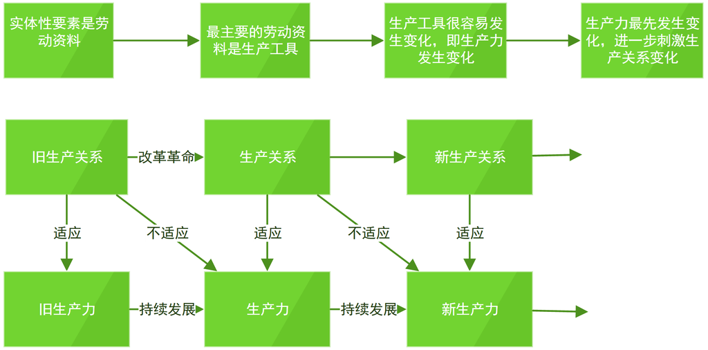

> 人类社会发展的规律：生产关系要不断适应生产力的发展，生产关系的不断前进代表着人类社会的发展

### 11.2.2 2. 经济基础与上层建筑

生产关系≈经济基础

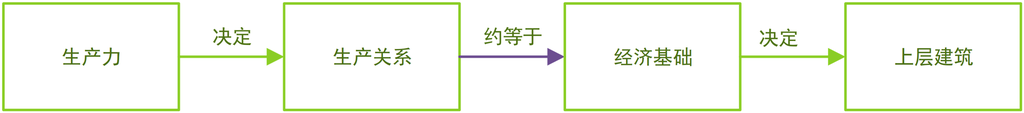

#### 11.2.2.1 a. 经济基础

经济基础是社会一定发展阶段的生产力所决定的生产关系的总和

1. 社会一定发展阶段上的基本经济制度（一个国家最基本的经济制度）
2. 是社会**占统治地位的**生产关系各个方面的总和

#### 11.2.2.2 b. 上层建筑

上层建筑是建立在一定经济基础之上的意识形态以及相应的制度、组织和设施

1. 观念上层建筑——社会意识：  
   意识形态（政治/法律思想，道德，艺术，宗教，哲学）
2. 政治上层建筑——社会存在：  
   制度，组织，设施（政治法律制度，军队、警察、法庭、监狱）
3. 政治上层建筑为意识形态提供保证，意识形态为政治上层建筑提供依据和精神指导

#### 11.2.2.3 c. 经济基础与上层建筑

1. 经济基础决定上层建筑
   1. 经济基础是上层建筑赖以产生. 存在和发展的物质基础。
   2. 经济基础的性质决定上层建筑的性质，有什么样的经济基础就有什么样的上层建筑。
   3. 经济基础的变更必然引起上层建筑的变革，并决定着其变革的方向。
2. 上层建筑反作用于经济基础  
   当它为适合生产力发展要求的经济基础服务时，就成为推动社会发展的进步力量，反之，就会成为阻碍社会发展的消极力量。

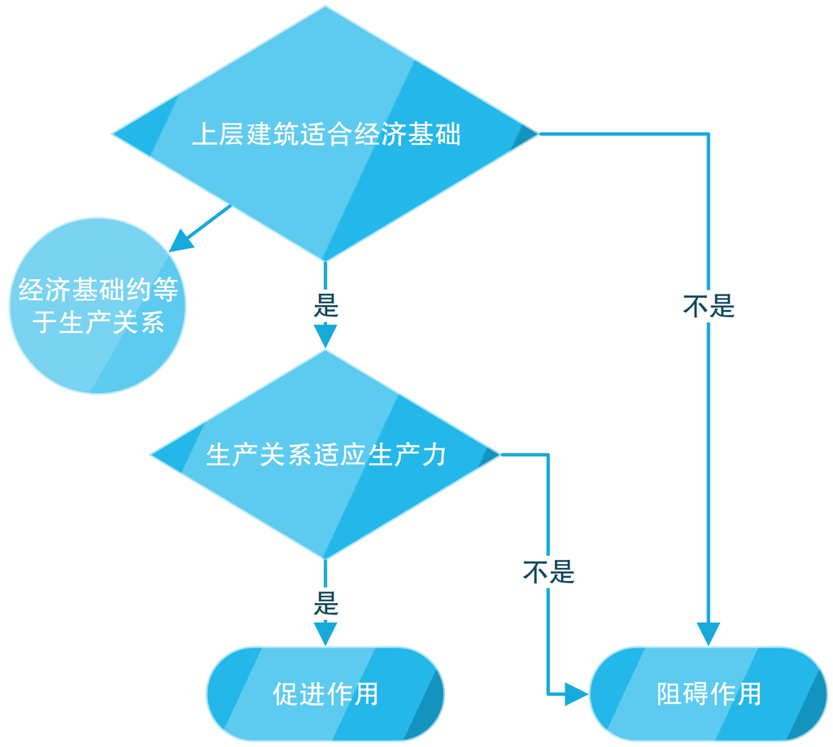

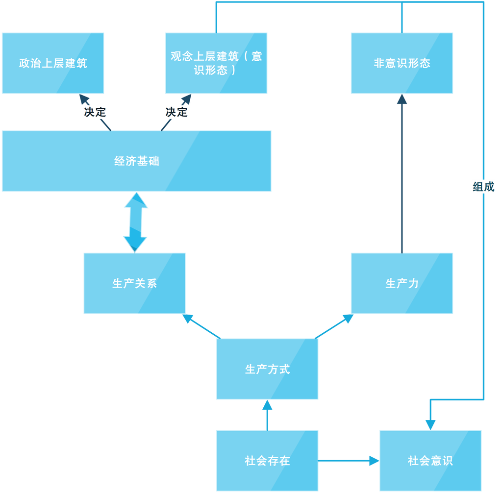

# 12 第十一讲 唯物史观（二）

## 12.1 一、社会历史发展动力

矛盾是动力 [^5]

基本矛盾是根本动力，阶级斗争是直接动力，科学革命是强大杠杆

1. 社会基本矛盾是社会发展的**根本动力**
   1. 基本矛盾：生产力和生产关系，经济基础和上层建筑的矛盾（社会存在与社会意识）
   2. 原因：*P131*
      1. 贯穿社会发展始终
      2. 决定社会中其他矛盾的存在和发展
2. 社会基本结构  
   3. 经济结构——经济基础  
   4. 政治结构——政治上层建筑  
   5. 观念结构——观念上层建筑
3. 社会形态的更替  
   6. 原始社会——无阶级社会  
   7. 奴隶社会  
   8. 封建社会  
   9. 资本主义社会  
   10. 社会主义社会——初级共产主义社会

   > 阶级社会  
   > 文明社会从阶级社会开始  
   > 阶级之所以会产生是因为生产力的发展  
   > 资本主义社会取代封建社会，是因为原有的封建社会生产关系不能适应生产力，通过阶级体现，资产阶级推翻封建阶级的统治

   > 阶级是生产力的表现  
   > 生产力与生产关系，经济基础与上层建筑之间的矛盾可以表现为阶级之间的矛盾
4. 阶级、阶级斗争及其在阶级社会发展中的作用
   1. 阶级：阶级是一个经济范畴，也是一个历史范畴
   2. 阶级斗争 *P137*
      1. 内涵：阶级利益**根本冲突**的**对抗阶级**之间的对立和斗争
      2. 根源：根源于阶级之间物质利益的根本对立，根源于**社会经济关系**的冲突
      3. 实质：经济利益

   阶级斗争是阶级社会发展的**直接动力**

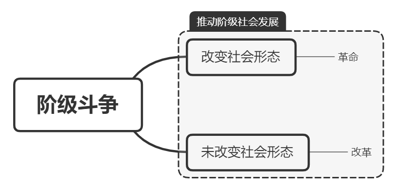

   > 改革一般都是自上而下，革命一般都是自下而上。  
   > 明治维新后，日本进入资本主义社会，采用二元君主制（一个是天皇，一个是议会）天皇占主导地位，仍然是君主专制，故明治维新是改革，不是革命
- 社会革命的实质和作用 *P140*
- 科学技术在社会发展中的作用 *P144*

  > 生产力=劳动者+生产工具+生产要素×科技+管理（科技的作用越来越大）
  - **科技革命是推动经济和社会发展的强大杠杆**
    - 对生产方式产生了深刻影响
    - 对生活方式产生了巨大影响
    - 促进了思维方式的变革
  - **正确把握科学技术的社会作用（两重性）**  
    科学技术在高度发展造福人类的同时，也带来了许多全球性问题

## 12.2 二、人民群众创造历史

1. 唯物史观——群众史观
2. 唯心史观——英雄史观——人民群众是历史中的惰性因素
   1. 分类
      1. 唯意志论的英雄史观

         > 梁启超：历史者，英雄之历史也。
      2. 宿命论的英雄史观

         > 黑格尔：“宇宙精神”是历史必然性的基础，历史人物不过是“宇宙精神”的受托人。
   2. 错误
      1. 否认历史发展的客观规律
      2. 逗人人民群众是历史的创造者
   3. 根源
      1. 认识根源：英雄人物在历史上的作用比一般人更大更突出
      2. 社会历史根源：生产力水平限制了人们的视野
      3. 阶级根源：夸大脑力劳动作用，贬低物质生产作用

> 逻辑关系说明  
> 人类社会本质上是实践的
> - **物质生产实践**
>   - **本质和核心是：生产方式**
>     - 生产方式包括：生产力和生产关系（生产力决定生产关系，**生产力是基础**）
>       - **生产力包括**
>         - 渗透性要素
>         - **实体性要素**
>           - **劳动者是主体，劳动者是人民群众**
> - 社会政治实践
> - 科学文化实践

### 12.2.1 人民群众是历史的创造者

1. 人民群众的涵义  
   **一切对社会历史发展起推动作用的人们**。不同的历史时期，人民群众有不同的内容，不同的阶级，其中最稳定的**主体部分始终是从事物质资料生产的劳动群众**。
2. 人民群众在历史创造过程中的具体作用 *P151*
   1. 社会物质财富的创造者
   2. 社会精神财富的创造者
   3. 社会变革的决定力量
3. 人民群众创造历史的活动受到一定社会历史条件的制约
   1. 经济条件——经济结构
   2. 政治条件——政治结构
   3. 文化条件——观念结构
> - 经济结构
>   - 广义经济结构：生产方式
>     - 生产力
>     - 生产关系
>   - 狭义经济结构：经济关系或经济制度
>     - 经济基础
> - 政治结构
> - 观念结构

### 12.2.2 个人在社会历史中的作用

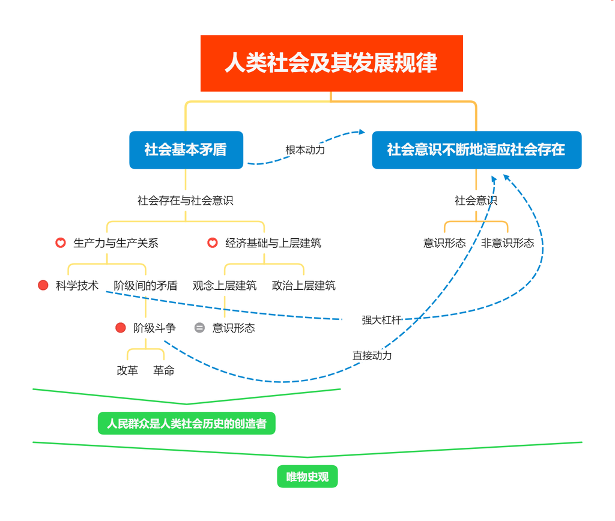

# 13 第十三讲 资本主义社会的本质

> 研究人类社会：
> - 经济、政治、观念
> - 经济基础、上层建筑

## 13.1 一、资本主义的形成

### 13.1.1 资本主义生产关系的形成

- 14C~15C资本主义萌芽
  - 小商品经济
  - 商人和高利贷者
- 15C~16C资本的原始积累

  > 生产资料和生产者的分离
  - 暴力手段剥夺农民的土地——英国圈地运动
  - 暴力手段掠夺货币财富
- 资本主义生产方式的形成：商品经济

  > 小商品经济→商品经济  
  > 雇佣关系、劳动力成为商品
1. 商品经济 *P160*

   > 以交换为目的而进行生产的经济形式  
   > 自然经济是自给自足的经济，生产为了直接满足生产者个人需要
   1. **社会分工**的出现：社会劳动划分并独立化为不同部门和行业
   2. 生产资料和劳动产品属于不同所有者
2. 商品的二因素
   1. 使用价值——自然属性
   2. 价值——社会属性（商品的本质因素）  
      凝结在**商品**中的**无差别的人类劳动**，即人类脑力和体力的耗费
   3. 价值和使用价值的辩证关系/对立统一关系
      1. 对立性：价值和使用价值不可兼得

         > 可以理解为价值是“金钱”，用来和别人进行交换，商品生产者生产商品不是为了取得使用价值，而是创造价值和别人交换
      2. 统一性：商品同时具有使用价值和价值，使用价值是价值的物质承担者，价值寓于使用价值中
   4. 具体劳动和抽象劳动的辩证关系/对立统一关系
      1. 基本内涵
         1. 具体劳动：生产一定使用价值的具体形式的劳动
         2. 抽象劳动：无差别的一般人类劳动，即体力和脑力消耗
      2. 对立统一
         1. 不是各自独立存在的两种劳动或两次劳动，时间空间上是统一的
         2. 具体劳动是劳动的自然属性，抽象劳动是劳动的社会属性
3. 价值量的决定
   1. 价值量：社会必要劳动时间
      1. 质的规定
      2. 量的规定
4. **★** **价值规律** *P167*
   1. **含义**
      1. 价值量是由生产商品的社会必要劳动时间决定的
      2. 商品交换以价值量为基础，按照等价交换的原则进行
   2. 作用
      1. 自发的调节生产资料和劳动力在社会各生产部门的比例.
      2. 自发的刺激社会生产力的发展
      3. 自发的调节社会收入的分配
   3. **价值规律的表现形式：价格围绕价值上下波动**

## 13.2 二、资本主义的经济基础

1. 劳动力成为商品和货币转化为资本
   1. 劳动力成为商品 *P180*
      1. 劳动力：劳动力是指人的劳动能力（体力和脑力的总和），劳动力的使用即劳动
      2. 基本条件：
         1. 劳动者是自由人，能够把自己的劳动力当做商品来支配
         2. 劳动者没有别的商品可以出卖，自由得一无所有，没有任何实现自己的劳动力所必需的物质条件
      3. **★** 劳动力商品的特点：劳动力的使用价值是价值的源泉，在消费过程中能创造新的价值，并且这个新的价值比劳动力本身的价值更大。

         > 劳动力可以创造新的价值，花1块钱雇佣人生产出大于1块钱的产品
2. 货币转化为资本
   1. 资本的含义：资本是可以带来剩余价值的价值.能够带来更多价值的钱

      > 货币本身不是资本，只有它能够带来剩余价值才是资本
   2. 资本的划分
      1. 不变资本C：生产资料形态存在的资本，生产过程中被消耗，生产出新的产品

         > 经过生产过程，它的价值随着物质形态的改变，转移到新产品中去，没有发生任何价值量的变化，价值不会增值
      2. 可变资本V：可变资本指的是资本家用于购买劳动力的那一部分资本。

         > 劳动力在使用过程中，不仅能够创造出补偿劳动力价值的价值，而且能创造出剩余价值，使资本增值。这个剩余价值本身是可变化的，从而转化为劳动力的那部分资本在生产过程中改变自己的价值量，马克思称之为可变资本。
   3. 公式
      1. 资本的有机构成=C/V

         > 一个国家或一个生产部门的资本有机构成，不可能长期不变，而是呈现不断提高的趋势。因为，资本家为了追逐尽可能多的利润和在激烈的竞争中保存自己，击败对手,总是竭力改进生产技术,采用新的生产设备，提高劳动生产率。而劳动生产率的提高，就意味着每个工人在一定时间内所推动的生产资料数量相应增多，意味着资本技术构成的提高。而资本技术构成的提高，反映在资本价值构成上,不变资本部分所占比重相对增多,可变资本部分所占比重相对减少，从而导致社会的或部门的资本平均有机构成逐步提高。
      2. 商品的价值W=不变资本C+可变资本V+剩余价值（利润m）
      3. 剩余价值率 m'=m/V=剩余劳动时间/必要劳动时间=剩余劳动/必要劳动
         1. 剩余劳动时间

            > 指劳动者的劳动时间中用于生产维持劳动者自身及其家庭生活所必需的生活资料的时间以外的部分。在剩余的劳动时间内，生产剩余的产品或剩余价值
         2. 必要劳动时间

            > 必要劳动时间指劳动者的劳动时间中用于生产维持劳动者自身及其家庭生活所必需的生活资料的那部分时间。在必要劳动时间内，生产必要产品或必要价值。
   4. 生产剩余价值的两种基本方法
      1. 绝对剩余价值：必要劳动时间不变，延长剩余劳动时间来获得绝对剩余价值

         > 生产某一产品需要必要劳动时间4小时，4小时内生产不出产品
      2. 相对剩余价值：总劳动时间不变，压缩必要劳动时间，例如提高生产力

## 13.3 三、资本主义的上层建筑

（略）

- 政治制度和意识形态
  - 国家、政治制度以及本质
    - 国家职能及本质
    - 资本主义制度及本质
  - 意识形态以及本质
    - 意识形态的形成
    - 特点和本质

# 14 第十四讲 资本主义的发展及其趋势

## 14.1 一、垄断资本主义的形成与发展 *P213*

1. 自由竞争资本主义 19c70s以前
2. 垄断资本主义（生产集中和资本集中） 19c末20c初
   1. 私人垄断资本
   2. 国家垄断资本
3. 原因：生产力的发展

## 14.2 二、当代资本主义的新变化

1. 二战后资本主义新变化的特点
   1. 表现
      1. 生产资料所有制：
         1. 二战以前：自由竞争阶段，个体资本所有制、私人股份资本所有制
         2. 二战以后：国家资本所有制、法人资本所有制
      2. 劳资关系和分配关系
         1. 二战以前：泰罗制，福特制（简单的雇佣关系，干的越多给的越多，剥削的也就越多）
         2. 二战以后：
            1. 职工参与决策
            2. 终身雇佣制度（只有日本有，现在越来越少了）
            3. 职工持股
            4. 普及化、全民化的社会福利制度

               > 西方福利制度的弊端，劳动积极性差，税收压力大
      3. 社会阶层和阶级结构的变化
         1. 资本家不再直接经营企业，经理成为实际控制者（CEO 董事长）
         2. 知识型和服务型劳动者数量不断增加
      4. 经济调节机制和经济危机形态的变化
         1. 70s滞胀危机（凯恩斯主义）
         2. 自由主义取代凯恩斯主义
         3. 金融投机领域冲击实体行业（虚拟经济）
         4. 2008 次贷危机
      5. 政治制度多元化
   2. 原因 *P239*
      1. 科学技术革命和生产力的发展是根本推动力量（克林顿 信息高速公路）
      2. 工人争取自身权益
      3. 社会主义制度初步显示的优越性产生巨大影响（法国：要么灭亡，要么马克思）
      4. 主张改良主义的政党的改革发挥了重要作用

         > 伯尼·桑德斯：政治主张“他将改变美国人财富严重不均的现状，打破财富影响政治的潜规则，提高富人的税率，推动美国的能源改革，应对气候变化。”“桑德斯是一位民主社会主义者，也是美国历史上第一名信奉社会主义的参议员”
   3. 实质 *P240*
      1. 人类社会发展一般规律和资本主义经济规律作用的结果
      2. 是资本主义制度基本框架内的变化，没有改变资本主义生产关系

### 14.2.1 生产资料所有制

- 个体资本所有制：生产资料的所有权与控制权统一于个体资本家
- 私人股份资本所有制：生产资料由私人资本家联合占有，所有权与控制权不再统一  
  买了阿里的股票，在阿里做决策时不会问你的意见
- 国家资本所有制：国家作为出资人，国有企业生产资料的所有权控制权属于国家
  - 凯恩斯主义，良性经济应是生产与需求达至平衡→政府
  - 与我国的国有企业不一样，为私人垄断资本的发展提供服务和保障。美国政府的首脑是总统，总统由人民选出，总统上位却要靠财团/资本家
- 法人资本所有制：法人，一个机构/企业，生产资料的所有权与控制权均多元化  
  阿里入股某某

| 制度 | 所有权 | 控制权 |
| --- | --- | --- |
| 个体资本所有制 | 单一 | 单一 |
| 私人股份资本所有制 | 多元 | 单一 |
| 国家资本所有制 | 国家 | 国家 |
| 法人资本所有制 | 多元 | 多元 |

资本主义社会中，生产逐步社会化，所有权，控制权变多元化

## 14.3 三、资本主义的历史地位和发展趋势

1. 历史地位，显示了巨大的历史进步性 （资本主义不是人类社会的最终形态）
2. 资本主义为社会主义所代替的历史必然性
   1. 资本主义内在矛盾
   2. 资本主义向社会主义过度是一个长期的历史过程
      1. 资本主义发展不平衡
      2. 资本主义目前还有很大适应能力
[^1]: 参考第八讲 如何认识世界: 实践为何是认识的基础
[^2]: 参考第四讲：规律及其客观性
[^3]: 参考第八讲 如何认识世界: 实践为何是认识的基础
[^4]: 见第四讲 人类社会的物质性
[^5]: 见第六讲 物质世界为何运动："同一性以斗争为前提，斗争性寓于同一性之中，为同一性所制约，矛盾双方既对立又统一，推动事物运动变化发展"